# 6_data_vis_1 slides

```python
import numpy as np
```

### Plotting and Visualization Using `Matplotlib`

- Making plots is one of the most critical tasks in data science
- `Matplotlib` is a desktop package for creating primarily 2D publication-ready plots
  - Inspired by MATLAB and commands almost equivalent across MATLAB and Matplotlib
- `Matplotlib` has spawned many add-on toolkits for data visualization that build on top of `Matplotlib`

### Some Popular Plotting Tools

- Seaborn: https://seaborn.pydata.org/examples/index.html
  - Desktop publishing with best practices to that is based on research on how people best perceive information
  - Excellent default parameters
- Plotly (https://plot.ly/python/)
  - Has an API for Python (as well as other languages)
  - The app itself is built on Python and DJANGO
  - The same company that created Dash

### Some Popular Plotting Tools - Cont'd

- Dash by plotly (https://dash.plot.ly/gallery)
  - Intuitive to use, elegant design
  - Support interactive visualization
- Bokeh (https://bokeh.pydata.org/en/latest/docs/gallery.html)
  - Python interactive visualization for web browsers
- plotnice (aka. ggplot2) (https://plotnine.readthedocs.io/en/stable/index.html)
  - `plotnine` is an implementation of a grammar of graphics in Python
  - based on ggplot2, the most popular libry used in with the R language

### Matplotlib: a Brief Intro

- `Matplotlib` can be overwhelming, a good place to start is the gallery (https://matplotlib.org/gallery.html)
- A multitude of plots to use for different scenarios
- `matplotlib`'s main module is `pyplot`
  - Imported using the `plt` alias

```
import matplotlib.pyplot as plt
```

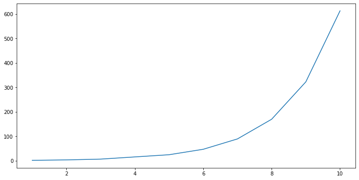

```python
y = [1.9**i for i in x ]
plt.plot(x, y)
```

#### Plot Figure and Axes

- Plots in Matplotlib reside within a Figure object
  - A figure contains the overall window where plotting happens
    - Contains the title axes, labels, ticks, etc..

```
plt.figure()
```

- Figures are empty by default. Therefore, you need to add a axes (plot) to visualize your data
- To add a plot, you need to determine the geometry and indicate where you want the plot to go
  - This returns the axes of a new subplot. It's an object of type `AxesSubplot`

```
fig.axes(rect)
# or
fig.add_subplot(rect)
```

- Therefore, Figure and plot/subplot (axes) are two different things

[figure not shown]

```python
fig = plt.figure()
```

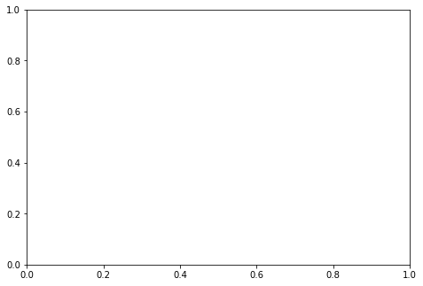

```python
fig = plt.figure()
# add_axes takes a rectangle [x0, y0, width, height]
fig.add_axes([0, 0, 1,1])
```

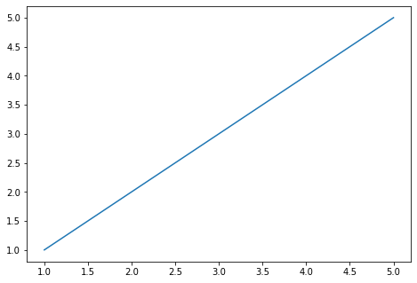

```python
fig = plt.figure()
# add_axes takes a rectangle [x0, y0, width, height]
ax = fig.add_axes([0, 0, 1,1])
ax.plot([1,2,3,4,5], [1,2,3,4,5])
```

```
ax is of type <class 'matplotlib.axes._subplots.AxesSubplot'>
```

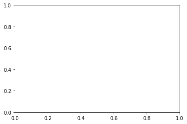

```python
fig = plt.figure()
ax = fig.add_subplot()
print(f"ax is of type {type(ax)}")
```

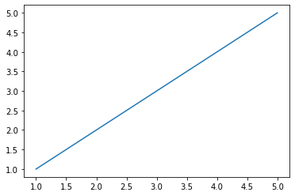

```python
fig = plt.figure()
ax = fig.add_subplot()
ax.plot([1,2,3,4,5], [1,2,3,4,5])
```

### Plotting Steps

- When you issue the command plt.plot(x, y ), the following happens
  - Matplotlib uses the figure created in a cell or creates one if none exists
  - Uses the last axes used or creates one if necessary

    ```
    fig = plt.figure()
    ax = fig.add_subplot()
    ax.plot([1,2,3,4,5], [1,2,3,4,5])
    ```

- Is equivalent to

```
plt.plot([1,2,3,4,5], [1,2,3,4,5])
```

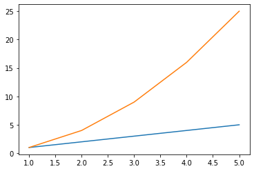

```python
# automatically plot on any cerated figure and axis
fig = plt.figure()
plt.plot([1,2,3,4,5], [1,2,3,4,5])
plt.plot([1,2,3,4,5], [1,4,9,16,25])
```

### Creating Multiple Subplots

- It is possible to draw multiple plots (subplots) in one figure using the `subplots()` or `add_subplot()` functions
  - Each subplot has its own setos axis.
- Subplot layout is organized in rows and columns
  - A subplot needs to know where in the row/column layout it belongs

```
add_subplot(num_rows, num_cols, position_of_subplot)
```

```python
# Sample data
x = [1,2,3,4,5]
y_1 = [1,2,3,4,5]
y_2 = [i**2 for i in x]
y_3 = [i**3 for i in x]
y_4 = [i**4 for i in x]

x, y_1, y_2, y_3, y_4
```

```
([1, 2, 3, 4, 5],
 [1, 2, 3, 4, 5],
 [1, 4, 9, 16, 25],
 [1, 8, 27, 64, 125],
 [1, 16, 81, 256, 625])
```

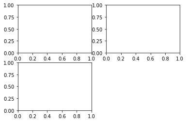

```python
# creating the subplots
fig = plt.figure()

ax1 = fig.add_subplot(2,2,1) # equivalent ot  ax1 = fig.add_subplot(221)
ax2 = fig.add_subplot(2,2,2) # equivalent ot  ax1 = fig.add_subplot(222)
ax3 = fig.add_subplot(2,2,3) # equivalent ot  ax1 = fig.add_subplot(223)
```

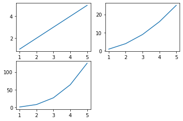

```python
# using add_subplot

fig = plt.figure()

ax1 = fig.add_subplot(2,2,1) # equivalent ot  ax1 = fig.add_subplot(221)
ax2 = fig.add_subplot(2,2,2) # equivalent ot  ax1 = fig.add_subplot(222)
ax3 = fig.add_subplot(2,2,3) # equivalent ot  ax1 = fig.add_subplot(223)

ax1.plot(x, y_1)
ax2.plot(x, y_2)
ax3.plot(x, y_3)
```

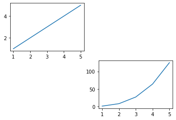

```python
fig = plt.figure()

ax1 = fig.add_subplot(2,2,1) # equivalent ot  ax1 = fig.add_subplot(221)
ax2 = fig.add_subplot(2,2,4) # equivalent ot  ax1 = fig.add_subplot(224)

ax1.plot(x, y_1)
ax2.plot(x, y_3)
```

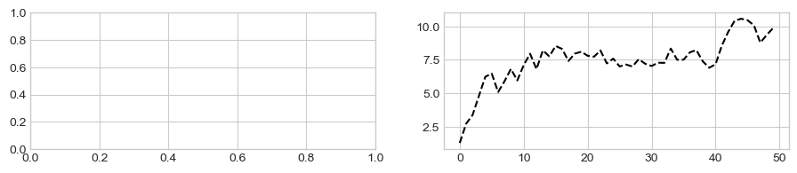

```python
# plot uses the last plot used.
fig = plt.figure(figsize=(11,2))
ax1 = fig.add_subplot(1,2,1) # equivalent ot  ax1 = fig.add_subplot(221)
ax2 = fig.add_subplot(1,2,2) # equivalent ot  ax1 = fig.add_subplot(222)
_ = plt.plot(np.random.randn(50).cumsum(),  'k--')
```

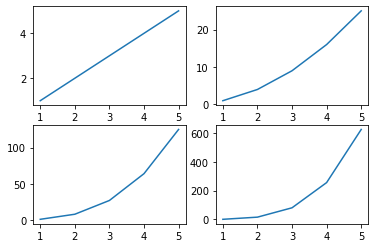

```python
# Using subplot()

plt.subplot(2,2,1)
plt.plot(x, y_1)

plt.subplot(2,2,2)
plt.plot(x, y_2)

plt.subplot(2,2,3)
plt.plot(x, y_3)

plt.subplot(2,2,4)
plt.plot(x, y_4)
```

### Creating an Array of Subplots

- Creating an array of subplots is a common task
- `matplotlib` includes a function that generates the fig and all the plots using a single function
- The plots car share the same x-axis or y-axis,
- Many other options to control the spacing padding, figure size, etc.

```
[[<AxesSubplot:> <AxesSubplot:> <AxesSubplot:>]
 [<AxesSubplot:> <AxesSubplot:> <AxesSubplot:>]]
---------------------
```

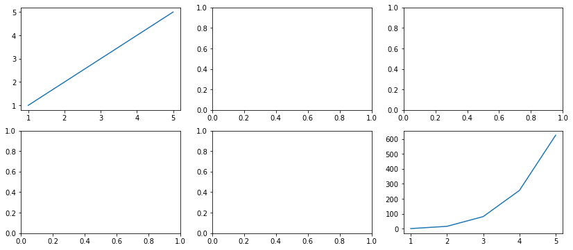

```python
fig, axes = plt.subplots(2,3, figsize=(14,6))
print(axes)

print("---------------------")

axes[0,0].plot(x, y_1)
axes[1,2].plot(x, y_4)
```

### Basic Plotting Parameters - Cont'd

- Plot have various functions to customize them
- Options are either:
  - plot specific
    - e.g. plot size, plot title, x-axis lebel, witespace, legend etc.
  - Line color, Line type (e.g.: dashed, width=2), Labels

```
python
plt.plot(x,y, color='red', linestyle='--')
```

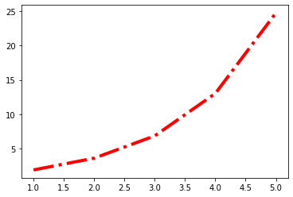

```python
y = [1.9**i for i in x ]
plt.plot(x,y, color='red', linestyle='-.', linewidth=4)
```

### Basic Plotting Parameters - Cont'd

- In addition to the data, `plot` accepts a string abbreviating color and line style
  - This is a convenience

    ```
    plt.plot(x,y, 'rx')
    # or
    plt.plot(x,y, 'k--')
    ```

- `plt.plot(x,y, 'k--')` can be expressed as `plt.plot(x,y, color='k', linestyle='--')`
- You can also specify color using hex code

[figure not shown]

```python
y = 1.9**x
plt.plot(x,y, 'k--')

y = 30*x + 4
plt.plot(x,y, 'rx')


y = 40*x + 4
plt.plot(x,y, color='#feb24c')
```

### Plot Legend

- Adding legends is critical for identifying plot elements
- The easiest way to add a legend is to pass a label when adding each element and calling the legend() function on the plot
  - the label can be a `latex` equation
- The legend is placed on the plot in a way that interferes the least with the plot
  - You can change the location of the legend manually

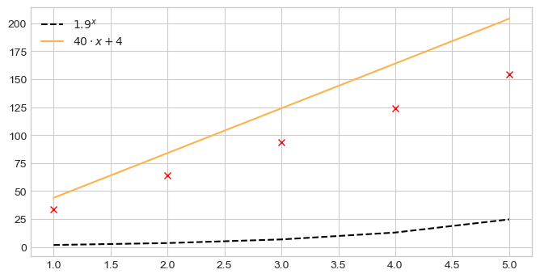

```python
plt.figure(figsize=(8,4))

y = [1.9**i for i in x]
plt.plot(x, y, 'k--', label= "$1.9^x$")

y = [30*i + 4 for i in x]
plt.plot(x, y, 'rx', label= "_no_legend_")


y = [40*i + 4 for i in x]
plt.plot(x ,y, color='#feb24c', label= "$ 40 \cdot x + 4$")

plt.legend()
```

### Plot Labels

- The minimum required labels to describe a plot are meaningful `x` and `y` label, and a plot title
- Axes can have a title, and so does the figure
- Title and labels can be customized
  - Change font type and size, color, etc.

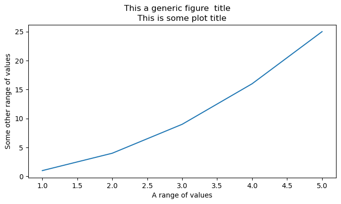

```python
fig = plt.figure(figsize=(8,4))
ax = fig.add_subplot()
_ = ax.plot([1, 2, 3, 4, 5], [1, 4, 9, 16, 25])

fig.suptitle('This a generic figure  title')
ax.set_title("This is some plot title")
ax.set_xlabel("A range of values")

# can you guess why I am using _ =  here?
_ = ax.set_ylabel("Some other range of values")
```

### Changing Style Via Presets

- Matplot lib provides various style presets to improve the look and feel of the plots
  - The presets control the fonts, the colors, borders and line widths, etc.
  - See https://matplotlib.org/stable/gallery/style_sheets/style_sheets_reference.html !~

```
plt.style.use('seaborn-whitegrid')
```

[figure not shown]

```python
plt.style.use('seaborn-whitegrid')
fig, axes = plt.subplots(2,3, sharex=True, sharey=True, figsize=(8,3))

axes[0,0].plot(x, y_3)
axes[1,2].plot(x, y_4)

# Do not plt any whitespace between the subplots
# useful when sharing x and/or y
# used when it makes sense
plt.subplots_adjust(wspace=0, hspace=0)
```

### Anatomy of a Matplotlib Figure

- The features of a matplotlib figure (https://matplotlib.org/stable/gallery/showcase/anatomy.html#)

[figure not shown]